# R Notebook

```r
library(tidyverse)
library(janitor)
```

```r
titanic_data <- read_csv("data/titanic_decision_tree_data.csv") %>% clean_names()
```

```r
library(rpart)
library(rpart.plot)

shuffle_index <- sample(1:nrow(titanic_data))

# shuffle the data so class order isn't in order - need this for training/testing split later on
titanic_set <- titanic_data[shuffle_index, ]
```

Take only observations which have a survived flag (i.e. that aren’t missing) Turn your important variables into factors (sex, survived, pclass, embarkation) Create an age_status variable which groups individuals under (and including) 16 years of age into a category called “child” category and those over 16 into a category called “adult”. Drop the NA Drop any variables you don’t need (X1, passenger_id, name, ticket, far, cabin)

```r
titanic_set

titanic_set <-  titanic_set %>%
  filter(!is.na(survived)) %>%
  mutate(across(.cols = c(sex, survived, pclass, embarked),
                .fns = as_factor)) %>%
  mutate(age_status = as_factor(if_else(age > 16, "adult", "child"))) %>%
  select(-c(x1, passenger_id, name, ticket, fare, cabin)) %>%
  drop_na()

titanic_set <- titanic_set %>%
  mutate(survived = if_else(survived == 0, "No", "Yes"),
         pclass = case_when(
           pclass == 1 ~ "Upper",
           pclass == 2 ~ "Middle",
           pclass == 3 ~ "Lower"
         ))

titanic_set <- titanic_set %>%
  select(survived, everything())

titanic_set %>%
  mutate(survived = as_factor(survived))
```

```r
glimpse(titanic_set)
```

```r
library(GGally)

titanic_set %>%
  ggpairs()
```

[output not shown]

class, age , age status?

```r
# get how many rows we have in total to work out the percentage
n_data <- nrow(titanic_set)

# create a test sample index
test_index <- sample(1:n_data, size = n_data*0.2)

# create test set
titanic_test  <- slice(titanic_set, test_index)

# create training set
titanic_train <- slice(titanic_set, -test_index)
```

# check the amount of people that survived and who didnt survive for train/test

```r
titanic_test %>%
 janitor::tabyl(survived)
```

```
 survived  n  percent
       No 83 0.584507
      Yes 59 0.415493
```

```r
titanic_train %>%
  janitor::tabyl(survived)
```

```
 survived   n   percent
       No 341 0.5982456
      Yes 229 0.4017544
```

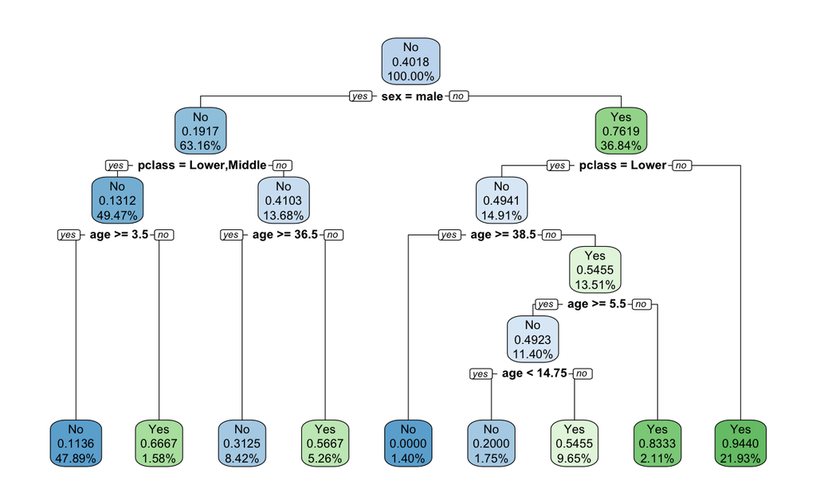

```r
titanic_fit <- rpart(
  formula = survived ~ .,
  data = titanic_train,
  method = 'class'
)

rpart.plot(titanic_fit,
           yesno = 2,
           fallen.leaves = TRUE,
           faclen = 6,
           digits = 4)
```

important variables:

- sex
- pclass
- sib_sp (changed so now not important)

highest chance of surviving:

- people who are not male and not lower class

40.18% of people survived (probability)

|  | survived |  |  |  |  |  |  |  |  |  |  |  |  |  |  | cover |
| --- | --- | --- | --- | --- | --- | --- | --- | --- | --- | --- | --- | --- | --- | --- | --- | --- |
| 12 | 0.00 | when | sex | is | female | & | pclass | is | Lower | & | age | >= |  |  | 38.5 | 1% |
| 8 | 0.11 | when | sex | is | male | & | pclass | is | Lower or Middle | & | age | >= |  |  | 3.5 | 48% |
| 52 | 0.20 | when | sex | is | female | & | pclass | is | Lower | & | age | is | 5.5 | to | 14.8 | 2% |
| 10 | 0.31 | when | sex | is | male | & | pclass | is | Upper | & | age | >= |  |  | 36.5 | 8% |
| 53 | 0.55 | when | sex | is | female | & | pclass | is | Lower | & | age | is | 14.8 | to | 38.5 | 10% |
| 11 | 0.57 | when | sex | is | male | & | pclass | is | Upper | & | age | < | 36.5 |  |  | 5% |
| 9 | 0.67 | when | sex | is | male | & | pclass | is | Lower or Middle | & | age | < | 3.5 |  |  | 2% |
| 27 | 0.83 | when | sex | is | female | & | pclass | is | Lower | & | age | < | 5.5 |  |  | 2% |
| 7 | 0.94 | when | sex | is | female | & | pclass | is | Middle or Upper |  |  |  |  |  |  | 22% |

female in the upper or middle class has the highest chance of surviving

| survived | pclass | sex | age | sib_sp | parch | embarked | age_status | pred |
| --- | --- | --- | --- | --- | --- | --- | --- | --- |
| No | Lower | male | 23.00 | 0 | 0 | S | adult | No |
| No | Lower | male | 17.00 | 1 | 1 | C | adult | No |
| No | Middle | male | 34.00 | 1 | 0 | S | adult | No |
| No | Lower | male | 32.00 | 0 | 0 | Q | adult | No |
| Yes | Middle | female | 40.00 | 1 | 1 | S | adult | Yes |
| Yes | Lower | male | 1.00 | 1 | 2 | S | child | Yes |
| No | Lower | male | 19.00 | 0 | 0 | S | adult | No |
| No | Middle | male | 26.00 | 0 | 0 | S | adult | No |
| Yes | Upper | female | 19.00 | 0 | 0 | S | adult | Yes |
| No | Lower | male | 49.00 | 0 | 0 | S | adult | No |

[output cut: 132 more lines]

```r
library(yardstick)

conf_mat <- titanic_test_pred %>%
              conf_mat(truth = survived, estimate = pred)

conf_mat
```

```
          Truth
Prediction No Yes
       No  67  13
       Yes 16  46
```

```r
accuracy <- titanic_test_pred %>%
 accuracy(truth = survived, estimate = pred)

accuracy
```

| .metric | .estimator | .estimate |
| --- | --- | --- |
| accuracy | binary | 0.7957746 |

[output not shown]

[output not shown]

```r
library(caret)

confusionMatrix(titanic_test_pred$pred, titanic_test_pred$survived)
```

```
Confusion Matrix and Statistics

          Reference
Prediction No Yes
       No  67  13
       Yes 16  46

               Accuracy : 0.7958
                 95% CI : (0.72, 0.8588)
    No Information Rate : 0.5845
    P-Value [Acc > NIR] : 8.094e-08

                  Kappa : 0.5826

 Mcnemar's Test P-Value : 0.7103

            Sensitivity : 0.8072
            Specificity : 0.7797
         Pos Pred Value : 0.8375
         Neg Pred Value : 0.7419
             Prevalence : 0.5845
         Detection Rate : 0.4718
   Detection Prevalence : 0.5634
      Balanced Accuracy : 0.7934

       'Positive' Class : No
```

random forest ##########

```r
rf_classifier
```

```
Ranger result

Call:
 ranger(survived ~ ., data = titanic_train, importance = "impurity",      num.trees = 1000, mtry = 2, min.node.size = 5)

Type:                             Classification
Number of trees:                  1000
Sample size:                      570
Number of independent variables:  7
Mtry:                             2
Target node size:                 5
Variable importance mode:         impurity
Splitrule:                        gini
OOB prediction error:             19.47 %
```